# Long Assignment - Improve sales of a company that sells luxury items

## Introduction to Data Science

Maria Bessa - up201704601

João Cunha - up202103227

### 1. Introduction

### 2. Business Understanding

### 3. Data Understanding

#### Numerical Variables

#### Categorical Variables

#### Summary of the data understanding

### 4. Data Preparation

### 5. Modeling

#### Full Dataset

#### Balanced Dataset

#### Comparison of models

### 6. Evaluation and Main Conclusions

### 7. Bonus

# 1. Introduction

The data to be used has been collected by a company during its operation. The company sells luxury items through its website and wants to improve success in its sales and better understand the behavior of the customers/users. For each user interaction, the company records values for a number of attributes possibly related to the success of the sale in a given e-commerce session. When the client buys the product, the variable bought has value 1, otherwise it is 0. A number of other variables describe the session.

# 2. Business Understanding

We approached this data science problem by following the CRISP-DM methodology.

The Cross Industry Standard Process for Data Mining (CRISP-DM) is a process model used with six phases that naturally describes the data science life cycle. It’s like a set of guardrails to help us plan, organize, and implement our data science (or machine learning) project. The first phase of this model is **business understanding** - **What does the business need?**

**Determine business objectives:** We were given a dataset from a company that sells luxury items. This dataset has information and data about the company's customers (possibly correlated with sales success). We chose has our target the variable **bought**. The variable **bought** can only assume 2 values, therefore, this is a **binary classification problem**.

**Business objective:** the company wants to improve success in its sales and understand the behavior of its customers.

**Assess the situation:** data in csv format collected by the company.

**Determine data mining goals:** Our target is a binary variable ('bought'), so this is a binary classification machine learning type of task. We want to obtain a model that will help us predict if a luxury item has been bought or not.

# 3. Data Understanding

Next is the Data Understanding phase. This step drives the focus to identify, collect, and analyze the data sets that can help us accomplish the project goals.

**Collect initial data:** The data was provided by the professors, so, it was not necessary to collect it ourselves.

First, we import the necessary libraries for proper data analysis and beyond. Then, we import the full dataset. We will only do the data understanding part of the full dataset since the balanced dataset was already worked on by the professors.

```python
#Majority of the libraries we used for the whole assignment
import numpy as np
import pandas as pd
import matplotlib.pyplot as plt
import seaborn as sns
import math
from sklearn.model_selection import train_test_split
from sklearn.neighbors import KNeighborsRegressor
from sklearn.neighbors import KNeighborsClassifier
from sklearn.model_selection import cross_val_score
from sklearn.model_selection import GridSearchCV
from sklearn.model_selection import ShuffleSplit
from sklearn.metrics import accuracy_score,recall_score,confusion_matrix,r2_score,precision_score, plot_confusion_matrix
from sklearn.metrics import confusion_matrix
from sklearn.tree import DecisionTreeClassifier
from sklearn.svm import SVC
from sklearn.neighbors import KNeighborsClassifier
from sklearn.naive_bayes import GaussianNB
from sklearn.neural_network import MLPClassifier
from sklearn.ensemble import RandomForestClassifier
import datetime as dt
import warnings
warnings.filterwarnings('ignore')

df_full = pd.read_csv("/Users/maria/Downloads/train_full.csv")
```

**Describing and exploring data:**

```python
df_full
```

|  | Unnamed: 0 | session_id | plaform | segment | customer_type | device_group | visitor_type | has_listing | has_used_search | has_recommendation | ... | has_add_to_bag | duration | view_qty | unique_product_qty | unique_browse_designer_qty | unique_browse_category_qty | is_subscribed | browser_name | country | bought |
| --- | --- | --- | --- | --- | --- | --- | --- | --- | --- | --- | --- | --- | --- | --- | --- | --- | --- | --- | --- | --- | --- |
| 0 | 0 | aae4be18-e8f9-41c6-8906-6fa41cd83f8a | website | without_segment | prospect | Mobile Web | new | 1 | 0 | 0 | ... | 0 | 0 | 1 | 0 | 0 | 1 | NaN | Safari | US | 0 |
| 1 | 1 | 62175cec-8acd-420c-ba11-0082901d6333 | website | without_segment | prospect | Mobile Web | returning | 0 | 0 | 1 | ... | 0 | 0 | 1 | 1 | 1 | 1 | NaN | Chrome | MX | 0 |
| 2 | 2 | e45c3886-bfeb-45c5-8d3f-00011d89a767 | mobile_app | FFACCESS-Bronze | customer | App | returning | 1 | 0 | 1 | ... | 0 | 27 | 10 | 1 | 1 | 1 | No | NaN | RU | 0 |
| 3 | 3 | 9fd5e56c-24e9-4974-9d69-e3509922d80d | mobile_app | without_segment | customer | App | returning | 1 | 0 | 0 | ... | 0 | 88 | 15 | 5 | 1 | 1 | Yes | NaN | RU | 0 |
| 4 | 4 | ddebea0b-a83f-459f-b0c4-d17efe4df69f | website | without_segment | prospect | Mobile Web | new | 0 | 0 | 0 | ... | 0 | 0 | 1 | 1 | 1 | 1 | NaN | Instagram App | US | 0 |
| ... | ... | ... | ... | ... | ... | ... | ... | ... | ... | ... | ... | ... | ... | ... | ... | ... | ... | ... | ... | ... | ... |
| 94995 | 99995 | 986cf576-3a4f-414b-94d3-33a693e848d9 | mobile_app | FFACCESS-Gold | customer | App | returning | 1 | 0 | 0 | ... | 1 | 2182 | 43 | 3 | 1 | 1 | Yes | NaN | HK | 1 |
| 94996 | 99996 | 1f36d141-b47b-478c-9210-264b9b373343 | website | FFACCESS-Platinum | customer | Mobile Web | returning | 1 | 1 | 1 | ... | 1 | 2040 | 48 | 11 | 3 | 7 | Yes | Safari | FR | 1 |
| 94997 | 99997 | 074f1f08-3549-4e7a-90a1-0c4f6444d451 | website | FFACCESS-Silver | customer | Desktop | returning | 0 | 0 | 1 | ... | 0 | 1118 | 8 | 0 | 0 | 0 | No | Chrome | US | 1 |
| 94998 | 99998 | 275f7cae-387d-4933-84bf-3d4218519c8a | website | without_segment | prospect | Mobile Web | new | 1 | 0 | 1 | ... | 1 | 3798 | 43 | 8 | 2 | 3 | Yes | Safari | US | 1 |
| 94999 | 99999 | 37cfece0-01d8-4787-a8f9-d0f1b619e76e | website | FFACCESS-Silver | customer | Desktop | new | 1 | 0 | 1 | ... | 1 | 1147 | 25 | 4 | 3 | 3 | Yes | Firefox | DE | 1 |

95000 rows × 21 columns

Our dataset has 95000 rows and 21 columns (variables).

```python
# check for columns with only NaNs
print("There are {} columns containing only NaN values.".format(df_full.isnull().all().sum()))
```

```
There are 0 columns containing only NaN values.
```

```python
#Checking for missing values
df_full.isnull().sum()
```

```
Unnamed: 0                        0
session_id                        0
plaform                           0
segment                           0
customer_type                     0
device_group                      0
visitor_type                      0
has_listing                       0
has_used_search                   0
has_recommendation                0
has_add_to_wishlist               0
has_add_to_bag                    0
duration                          0
view_qty                          0
unique_product_qty                0
unique_browse_designer_qty        0
unique_browse_category_qty        0
is_subscribed                 67313
browser_name                  26232
country                           4
bought                            0
dtype: int64
```

## Numerical variables

## duration

Session duration in seconds

```python
print('Missing values:',len(df_full[df_full.duration.isnull()]))
print('Values of 0:',len(df_full[df_full.duration==0]))
print('Percentage of values of 0 and missing values:',
      round((len(df_full[df_full.duration.isnull()]) + len(df_full[df_full.duration==0]))*100/len(df_full),1),'%')
print('Negative values: ', len(df_full[df_full.duration<0]))
print('\n',df_full.duration.describe())
```

```
Missing values: 0
Values of 0: 41417
Percentage of values of 0 and missing values: 43.6 %
Negative values:  0

 count    95000.000000
mean       332.473663
std        868.827560
min          0.000000
25%          0.000000
50%         15.000000
75%        223.000000
max      20295.000000
Name: duration, dtype: float64
```

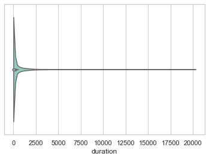

```python
ax = sns.violinplot(x="duration",
                    data=df_full[(df_full.duration>=0)],
                    cut=0, scale="width", palette="Set3")
plt.show()
```

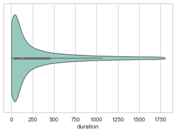

```python
ax = sns.violinplot(x="duration",
                    data=df_full[(df_full.duration>0) & (df_full.duration<=1800)],
                    cut=0, scale="width", palette="Set3")
plt.show()
```

The second plot looks way better than the first one because we chose a reasonable interval for the duration of sessions. It's a little absurd to have sessions with zero seconds. A session that lasted 0 seconds does not bring any valuable information.

## view_qty

Number of views in the session

```python
print('Missing values:',len(df_full[df_full.view_qty.isnull()]))
print('Values of 0:',len(df_full[df_full.view_qty==0]))
print('Percentage of values of 0 and missing values:',
      round((len(df_full[df_full.view_qty.isnull()]) + len(df_full[df_full.view_qty==0]))*100/len(df_full),1),'%')
print('Negative values: ', len(df_full[df_full.view_qty<0]))
print('\n',df_full.view_qty.describe())
```

```
Missing values: 0
Values of 0: 0
Percentage of values of 0 and missing values: 0.0 %
Negative values:  0

 count    95000.000000
mean        10.972179
std         31.213357
min          1.000000
25%          1.000000
50%          2.000000
75%          8.000000
max       1151.000000
Name: view_qty, dtype: float64
```

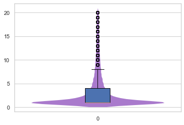

```python
fig, ax = plt.subplots()
sns.violinplot(data=df_full[df_full.view_qty<=20].view_qty, color="#af52f4", inner=None, linewidth=0, saturation=0.5)
ax.boxplot(df_full[df_full.view_qty<=20].view_qty, positions=np.array([0]), patch_artist=True)
plt.show()
```

## unique_product_qty

Number of distinct product page views within the session

```python
print('Missing values:',len(df_full[df_full.unique_product_qty.isnull()]))
print('Values of 0:',len(df_full[df_full.unique_product_qty==0]))
print('Percentage of values of 0 and missing values:',
      round((len(df_full[df_full.unique_product_qty.isnull()]) + len(df_full[df_full.unique_product_qty==0]))*100/len(df_full),1),'%')
print('Negative values: ', len(df_full[df_full.unique_product_qty<0]))
print('\n',df_full.unique_product_qty.describe())
```

```
Missing values: 0
Values of 0: 28829
Percentage of values of 0 and missing values: 30.3 %
Negative values:  0

 count    95000.000000
mean         2.766547
std          8.493634
min          0.000000
25%          0.000000
50%          1.000000
75%          2.000000
max        416.000000
Name: unique_product_qty, dtype: float64
```

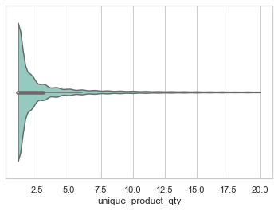

```python
ax = sns.violinplot(x="unique_product_qty",
                    data=df_full[(df_full.unique_product_qty>0) & (df_full.unique_product_qty<=20)],
                    cut=0, scale="width", palette="Set3")
plt.show()
```

## unique_browse_designer_qty

Number of distinct designer_id within the session

```python
print('Missing values:',len(df_full[df_full.unique_browse_designer_qty.isnull()]))
print('Values of 0:',len(df_full[df_full.unique_browse_designer_qty==0]))
print('Percentage of values of 0 and missing values:',
      round((len(df_full[df_full.unique_browse_designer_qty.isnull()]) + len(df_full[df_full.unique_browse_designer_qty==0]))*100/len(df_full),1),'%')
print('Negative values: ', len(df_full[df_full.unique_browse_designer_qty<0]))
print('\n',df_full.unique_browse_designer_qty.describe())
```

```
Missing values: 0
Values of 0: 14778
Percentage of values of 0 and missing values: 15.6 %
Negative values:  0

 count    95000.000000
mean         1.676105
std          3.374039
min          0.000000
25%          1.000000
50%          1.000000
75%          1.000000
max        158.000000
Name: unique_browse_designer_qty, dtype: float64
```

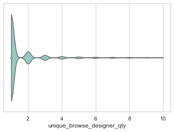

```python
ax = sns.violinplot(x="unique_browse_designer_qty",
                    data=df_full[(df_full.unique_browse_designer_qty>0) & (df_full.unique_browse_designer_qty<=10)],
                    cut=0, scale="width", palette="Set3")
plt.show()
```

## unique_browse_category_qty

Number of distinct category_id within the session

```python
print('Missing values:',len(df_full[df_full.unique_browse_category_qty.isnull()]))
print('Values of 0:',len(df_full[df_full.unique_browse_category_qty==0]))
print('Percentage of values of 0 and missing values:',
      round((len(df_full[df_full.unique_browse_category_qty.isnull()]) + len(df_full[df_full.unique_browse_category_qty==0]))*100/len(df_full),1),'%')
print('Negative values: ', len(df_full[df_full.unique_browse_category_qty<0]))
print('\n',df_full.unique_browse_category_qty.describe())
```

```
Missing values: 0
Values of 0: 22498
Percentage of values of 0 and missing values: 23.7 %
Negative values:  0

 count    95000.000000
mean         1.166042
std          1.353135
min          0.000000
25%          1.000000
50%          1.000000
75%          1.000000
max         84.000000
Name: unique_browse_category_qty, dtype: float64
```

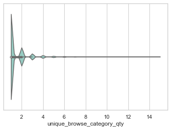

```python
ax = sns.violinplot(x="unique_browse_category_qty",
                    data=df_full[(df_full.unique_browse_category_qty>0) & (df_full.unique_browse_category_qty<=15)],
                    cut=0, scale="width", palette="Set3")
plt.show()
```

## Categorical variables

## customer_type

Identifies if a user has purchased before (customer/prospect)

```
prospect    75529
customer    19471
Name: customer_type, dtype: int64
```

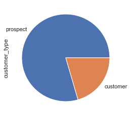

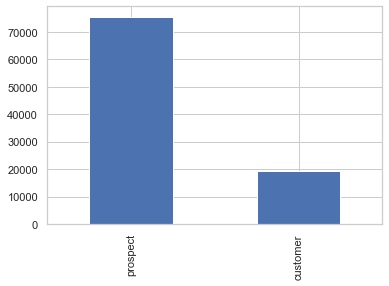

```python
print(df_full.customer_type.value_counts(dropna=False))
df_full.customer_type.value_counts(dropna=False).plot.pie()
plt.show()
df_full.customer_type.value_counts(dropna=False).plot.bar()
plt.show()
```

## device_group

Device Group (app/mobile web/desktop/etc.)

```
Mobile Web    52567
App           26232
Desktop       16201
Name: device_group, dtype: int64
```

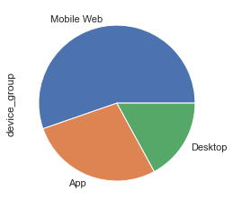

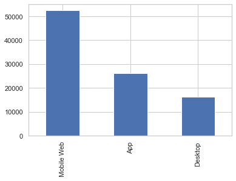

```python
print(df_full.device_group.value_counts(dropna=False))
df_full.device_group.value_counts(dropna=False).plot.pie()
plt.show()
df_full.device_group.value_counts(dropna=False).plot.bar()
plt.show()
```

We also have another variable called **"plaform"** that basically refers to the same thing as the device_group but has one less feature.

```
website       68768
mobile_app    26232
Name: plaform, dtype: int64
```

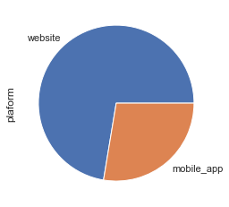

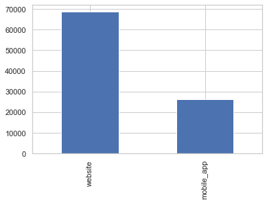

```python
print(df_full.plaform.value_counts(dropna=False))
df_full.plaform.value_counts(dropna=False).plot.pie()
plt.show()
df_full.plaform.value_counts(dropna=False).plot.bar()
plt.show()
```

## visitor_type

If the device is new in the company platform

```
new          48592
returning    46408
Name: visitor_type, dtype: int64
```

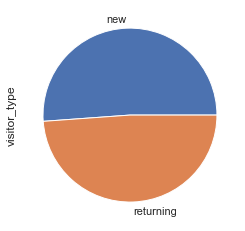

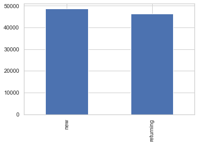

```python
print(df_full.visitor_type.value_counts(dropna=False))
df_full.visitor_type.value_counts(dropna=False).plot.pie()
plt.show()
df_full.visitor_type.value_counts(dropna=False).plot.bar()
plt.show()
```

## has_listing

Flag that indicates if the session has a listing view

```
1    50021
0    44979
Name: has_listing, dtype: int64
```

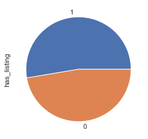

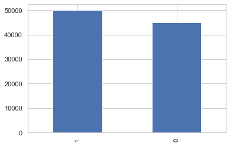

```python
print(df_full.has_listing.value_counts(dropna=False))
df_full.has_listing.value_counts(dropna=False).plot.pie()
plt.show()
df_full.has_listing.value_counts(dropna=False).plot.bar()
plt.show()
```

## has_used_search

Flag that indicates if the session has a search view

```
0    80466
1    14534
Name: has_used_search, dtype: int64
```

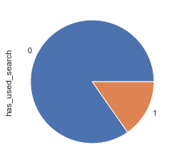

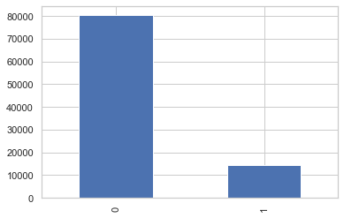

```python
print(df_full.has_used_search.value_counts(dropna=False))
df_full.has_used_search.value_counts(dropna=False).plot.pie()
plt.show()
df_full.has_used_search.value_counts(dropna=False).plot.bar()
plt.show()
```

## has_recommendation

Flag that indicates if the session has a recommendation view

```
0    65594
1    29406
Name: has_recommendation, dtype: int64
```

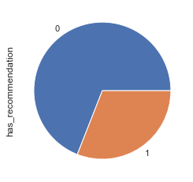

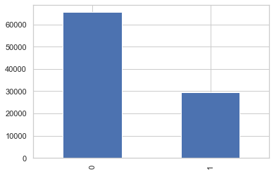

```python
print(df_full.has_recommendation.value_counts(dropna=False))
df_full.has_recommendation.value_counts(dropna=False).plot.pie()
plt.show()
df_full.has_recommendation.value_counts(dropna=False).plot.bar()
plt.show()
```

## has_add_to_wishlist

Flag that indicates if the session has an add_to_wishlist view

```
0    90468
1     4532
Name: has_add_to_wishlist, dtype: int64
```

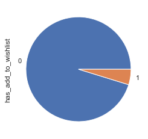

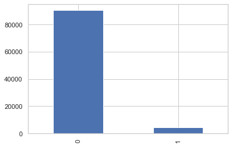

```python
print(df_full.has_add_to_wishlist.value_counts(dropna=False))
df_full.has_add_to_wishlist.value_counts(dropna=False).plot.pie()
plt.show()
df_full.has_add_to_wishlist.value_counts(dropna=False).plot.bar()
plt.show()
```

## has_add_to_bag

Flag that indicates if the session has an add_to_bag view

```
0    84191
1    10809
Name: has_add_to_bag, dtype: int64
```

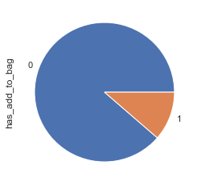

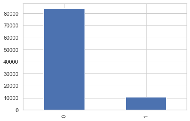

```python
print(df_full.has_add_to_bag.value_counts(dropna=False))
df_full.has_add_to_bag.value_counts(dropna=False).plot.pie()
plt.show()
df_full.has_add_to_bag.value_counts(dropna=False).plot.bar()
plt.show()
```

## is_subscribed

If the user is subscribed in the newsletter

```
NaN        67313
Yes        18640
No          9004
Unknown       43
Name: is_subscribed, dtype: int64
```

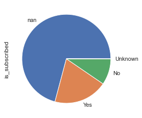

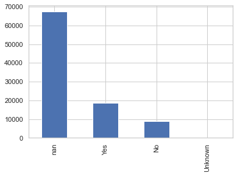

```python
print(df_full.is_subscribed.value_counts(dropna=False))
df_full.is_subscribed.value_counts(dropna=False).plot.pie()
plt.show()
df_full.is_subscribed.value_counts(dropna=False).plot.bar()
plt.show()
```

## browser_name

User agent browser name

```
Safari                     28487
NaN                        26232
Chrome                     22085
Instagram App               4448
Facebook App                3553
Google App                  1928
Samsung Browser             1570
Mobile Safari UIWebView     1317
Firefox                     1240
Edge                        1126
Yandex Browser               961
Opera                        783
Android WebView              590
HuaweiBrowser                120
Miui Browser                 111
Apple Mail                    62
WeChat App                    54
Snapchat                      39
Opera Mobile                  37
Firefox for iOS               34
Line App                      32
DuckDuckGo Browser            27
Naver                         23
Whale Browser                 17
UC Browser                    17
Sogou Explorer                15
Weibo                         14
Vivo Browser                  13
Default Browser               11
Silk                          10
QQBrowser                      7
HeyTapBrowser                  6
CM Browser                     4
Ecosia                         3
RDDocuments App                2
DareBoost Bot                  2
Sleipnir                       2
AliApp                         2
Puffin                         2
Playstation Browser            2
Iron                           1
Elements Browser               1
Mail Master                    1
Waterfox                       1
Netease Music                  1
WKBrowser                      1
Meizu Browser                  1
Coc Coc Browser                1
Android                        1
Tungsten Browser               1
Maxthon                        1
Edge Mobile                    1
Name: browser_name, dtype: int64
```

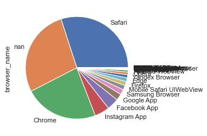

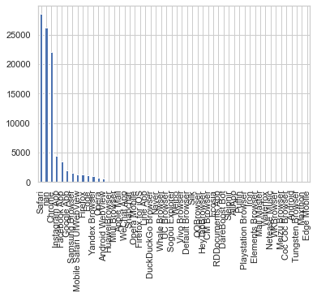

```python
print(df_full.browser_name.value_counts(dropna=False))
df_full.browser_name.value_counts(dropna=False).plot.pie()
plt.show()
df_full.browser_name.value_counts(dropna=False).plot.bar()
plt.show()
```

## country

Session client country

```
US    15772
RU    14418
BR     6046
GB     5874
IT     4152
      ...
BJ        1
TC        1
AQ        1
LC        1
GM        1
Name: country, Length: 163, dtype: int64
```

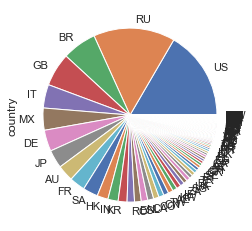

[figure not shown]

```python
print(df_full.country.value_counts(dropna=False))
df_full.country.value_counts(dropna=False).plot.pie()
plt.show()
df_full.country.value_counts(dropna=False).plot.bar()
plt.show()
```

```python
print(df_full.country.unique())
```

```
['US' 'MX' 'RU' 'AU' 'IN' 'PT' 'KR' 'CL' 'GB' 'AE' 'CN' 'HK' 'DE' 'GR'
 'PL' 'KW' 'LI' 'BR' 'AT' 'HR' 'CA' 'IT' 'SA' 'TW' 'ZA' 'VN' 'JP' 'FR'
 'RO' 'QA' 'ME' 'BH' 'ID' 'PE' 'ES' 'BE' 'PK' 'LB' 'IE' 'KZ' 'BG' 'PH'
 'NL' 'AR' 'IL' 'SE' 'NZ' 'GE' 'DO' 'DK' 'BY' 'AF' 'MD' 'TH' 'MY' 'UA'
 'LT' 'CH' 'EG' 'NO' 'CO' 'SG' 'BA' 'RS' 'KH' 'HU' 'MO' 'IS' 'OM' 'AM'
 'UY' 'MA' 'NG' 'AL' 'BB' 'EE' 'DZ' 'MK' 'SK' 'LU' 'AO' 'TR' 'PA' 'EC'
 'JO' 'IQ' 'BD' 'GH' 'CY' 'SI' 'AZ' 'CZ' 'MU' 'KG' 'MT' 'BN' 'FI' 'TN'
 'LV' 'CR' 'BS' 'SV' 'UZ' 'GT' 'AD' 'NP' 'HN' 'CM' 'KE' 'ET' 'AI' 'MC'
 'GP' 'JM' nan 'MW' 'SN' 'VE' 'VI' 'CI' 'MR' 'ZM' 'AW' 'CG' 'LK' 'PR' 'GU'
 'JE' 'GG' 'BM' 'SR' 'GI' 'TT' 'GY' 'BW' 'AQ' 'MN' 'MQ' 'HT' 'LC' 'SM'
 'GF' 'KY' 'BO' 'SL' 'LA' 'IC' 'KV' 'VC' 'TC' 'BJ' 'MZ' 'LS' 'RE' 'NC'
 'DM' 'MV' 'UG' 'TG' 'GL' 'PY' 'NI' 'GM']
```